# *S03 T02: Estructura d'una Matriu*

Anem a practicar i a familiaritzar-nos amb l'estructura de Matrius, dimensió, forma, vectorització i Broadcasting

**Documentación:**

- Numpy: https://www.w3schools.com/python/numpy/numpy_intro.asp
- Broadcasting: https://numpy.org/doc/stable/user/basics.broadcasting.html?highlight=broadcasting
- Indexing: https://numpy.org/doc/stable/user/basics.indexing.html?highlight=indexing
- Masking: https://numpy.org/doc/stable/reference/maskedarray.generic.html
- Matplotlib Image: https://matplotlib.org/stable/tutorials/introductory/images.html

**Librerias:**

```python
import numpy as np
from numpy import random
import numpy.ma as ma
import matplotlib.pyplot as plt
import matplotlib.image as mpimg
```

# **Nivell 1**

Treballem els conceptes de l'estructura d'una matriu, dimensió, eixos i la vectorització que ens permet reduir l'ús de for loops en operacions aritmètiques o matemàtiques.

## Exercici 1

- Crea un np.array d'una dimensió, que inclogui l'almenys 8 nombres sencers, data type int64. Mostra la dimensió i la forma de la matriu.

```python
num = random.randint(8,15) # definimos un numero entre 8 y 15.
array2=random.randint(100, size=(num)) #definimos array con numero d 0 a 99 con un tamoño de num. y una dimensión.

print(array2)

print(array2.dtype) # comprobamos el tipo

array64=array2.astype("int64") #lo convertimos a int64

print(array64.dtype)

print(f'Cabiamos el tipo de la matriz a cambiado de int32 a int 64')

print(f'\nLa matriz tiene {array64.ndim} dimensiones')
print(f'La matriz tiene la forma {array64.shape}, {len(array64)} elementos en {array64.ndim} dimensión')
```

```
[61 49  9 46  8 40 75 15]
int32
int64
Cabiamos el tipo de la matriz a cambiado de int32 a int 64

La matriz tiene 1 dimensiones
La matriz tiene la forma (8,), 8 elementos en 1 dimensión
```

## Exercici 2

- De la matriu de l'exercici 1, calcula el valor mitjà dels valors introduïts i resta la mitjana resultant de cada un dels valors de la matriu.

```python
mean= array64.mean() #definimos la media

# dos formaas de realizar la resta

print(np.subtract(array64, mean))
print("")
print(array64-mean)
```

```
[ 23.125  11.125 -28.875   8.125 -29.875   2.125  37.125 -22.875]

[ 23.125  11.125 -28.875   8.125 -29.875   2.125  37.125 -22.875]
```

## Exercici 3

- Crea una matriu bidimensional amb una forma de 5 x 5. Extreu el valor màxim de la matriu, i els valors màxims de cadascun dels seus eixos.

```python
myArray=random.randint(100,size=(5,5))

print(f'Creamos una matriz con forma {myArray.shape} y {myArray.ndim} dimensiones. \n')

print(myArray) # imprimimos array.



print(f'\nEl valor máximo de la matriz es {myArray.max()}.')
print(f'\nLos valores máximos en el eje vertical son {myArray.max(axis=0)}.')
print(f'\nLos valores máximos en el eje horizontal son {myArray.max(axis=1)}.')
```

```
Creamos una matriz con forma (5, 5) y 2 dimensiones.

[[77 41 87 66 99]
 [85 24 30 76 87]
 [88 86 34 51 56]
 [63 60 28 58 53]
 [57 80  6 85 38]]

El valor máximo de la matriz es 99.

Los valores máximos en el eje vertical son [88 86 87 85 99].

Los valores máximos en el eje horizontal son [99 87 88 63 85].
```

# **Nivell 2**

Treballem els conceptes de l'estructura d'una matriu, Broadcasting,indexació, Mask..

## Exercici 4

Mostreu-me amb exemples de diferents matrius, la regla fonamental de Broadcasting que diu : "les matrius es poden transmetre / broadcast si les seves dimensions coincideixen o si una de les matrius té una mida d'1".

**Les matrius es poden trasnmetre si les seves dimension**

1. Les seves dimension són iguals.
2. Una de les dimensions és 1.

*Les matrius tenen una dimension igual i la altra es 1*

```python
x=np.random.randint(0,10, size=(3,3))
y=np.random.randint(0,10, size=(3,1))

print(x)
print("")
print(y)

print('Realizamos suma y producto')
suma=x+y
prod=x*y
print("")
print(suma)
print("")
print(prod)
```

```
[[6 4 0]
 [0 3 1]
 [5 8 1]]

[[2]
 [6]
 [7]]
Realizamos suma y producto

[[ 8  6  2]
 [ 6  9  7]
 [12 15  8]]

[[12  8  0]
 [ 0 18  6]
 [35 56  7]]
```

```python
z=np.random.randint(0,10, size=(1,3))
print(x)
print("")
print(z)

print('Realizamos suma y producto')
suma=x+z
prod=x*z
print("")
print(suma)
print("")
print(prod)
```

```
[[6 4 0]
 [0 3 1]
 [5 8 1]]

[[4 0 4]]
Realizamos suma y producto

[[10  4  4]
 [ 4  3  5]
 [ 9  8  5]]

[[24  0  0]
 [ 0  0  4]
 [20  0  4]]
```

```python
z=np.random.randint(0,10, size=(1,3))
print(x)
print("")
print(z)

print('Realizamos suma y producto')
suma=x+z
prod=x*z
print("")
print(suma)
print("")
print(prod)
```

```
[[6 4 0]
 [0 3 1]
 [5 8 1]]

[[4 9 0]]
Realizamos suma y producto

[[10 13  0]
 [ 4 12  1]
 [ 9 17  1]]

[[24 36  0]
 [ 0 27  0]
 [20 72  0]]
```

```python
w=np.random.randint(0,10, size=(3,2))
print(x)
print("")
print(w)

print('Realizamos suma y producto')

try:
    suma=x+w
    prod=x*w
    print("")
    print(suma)
    print("")
    print(prod)

except:
    print("ValueError: operands could not be broadcast together with shapes (3,3) (3,2)")
```

```
[[6 4 0]
 [0 3 1]
 [5 8 1]]

[[2 5]
 [5 7]
 [0 6]]
Realizamos suma y producto
ValueError: operands could not be broadcast together with shapes (3,3) (3,2)
```

Es produeix un error pel fet que les dimensions no són iguals entre si i diferents de la unitat. No es poden transmetre matrius amb diferents formes.

**ValueError: operands could not be broadcast together with shapes (3,3) (3,2)**

## Exercici 5

Utilitza la Indexació per extreure els valors d'una columna i una fila de la matriu. I suma els seus valors.

```python
print(myArray)

print("")
print(myArray[0])

print(f'La primera fila de la matriz es {myArray[0]}.\n')
print(myArray[:,0])
print(f'La primera columna de la matriz es {myArray[:,0]}.\n')

suma=myArray[0]+myArray[:,0]

print(f'La suma de la primera columna con la primera fila de la matriz es {suma}, una matriz de una dimensión.')
```

```
[[77 41 87 66 99]
 [85 24 30 76 87]
 [88 86 34 51 56]
 [63 60 28 58 53]
 [57 80  6 85 38]]

[77 41 87 66 99]
La primera fila de la matriz es [77 41 87 66 99].

[77 85 88 63 57]
La primera columna de la matriz es [77 85 88 63 57].

La suma de la primera columna con la primera fila de la matriz es [154 126 175 129 156], una matriz de una dimensión.
```

## Exercici 6

Mask la matriu anterior, realitzeu un càlcul booleà vectoritzat, agafant cada element i comprovant si es divideix uniformement per quatre.

Això retorna una matriu de mask de la mateixa forma amb els resultats elementals del càlcul.

```python
# Utilizamos la matriz myArray
print(myArray)
print("")
mask=(myArray % 4 ==0)

print(mask)
```

```
[[77 41 87 66 99]
 [85 24 30 76 87]
 [88 86 34 51 56]
 [63 60 28 58 53]
 [57 80  6 85 38]]

[[False False False False False]
 [False  True False  True False]
 [ True False False False  True]
 [False  True  True False False]
 [False  True False False False]]
```

## Exercici 7

A continuació, utilitzeu aquesta màscara per indexar a la matriu de números original. Això fa que la matriu perdi la seva forma original, reduint-la a una dimensió, però encara obteniu les dades que esteu cercant.

```python
print(myArray[mask])
div4=(myArray[mask])

print(f'Los numeros divisibles por 4 de la matriz myArray son {div4}.')
```

```
[24 76 88 56 60 28 80]
Los numeros divisibles por 4 de la matriz myArray son [24 76 88 56 60 28 80].
```

### *alternativamente*

Alternativamente podemos utilizar el modulo numpy Maskered arrays donde la forma se conserva.

```python
myArray2=ma.masked_array(myArray,mask=myArray % 4) # el valor 0 se considerará booliano false

print('Imprimimos los valores divisibles entre 4 con las misma forma que la matriz original: \n')
print(myArray2)
print('\n La mascara:')
print(mask)
print('\nPodemos recuperar los valores que cumplen la condicion en una matriz de una dimensión (lista).')
print(myArray2.compressed())
```

```
Imprimimos los valores divisibles entre 4 con las misma forma que la matriz original:

[[-- -- -- -- --]
 [-- 24 -- 76 --]
 [88 -- -- -- 56]
 [-- 60 28 -- --]
 [-- 80 -- -- --]]

 La mascara:
[[False False False False False]
 [False  True False  True False]
 [ True False False False  True]
 [False  True  True False False]
 [False  True False False False]]

Podemos recuperar los valores que cumplen la condicion en una matriz de una dimensión (lista).
[24 76 88 56 60 28 80]
```

# **Nivel 3**

Manipulació d’imatges amb Matplotlib.

Carregareu qualsevol imatge (jpg, png ..) amb Matplotlib. adoneu-vos que les imatges RGB (Red, Green, Blue) són realment només amplades × alçades × 3 matrius (tres canals Vermell, Verd i Blau), una per cada color de nombres enters int8,

manipuleu aquests bytes i torneu a utilitzar Matplotlib per desar la imatge modificada un cop hàgiu acabat.

Ajuda:Importeu, import matplotlib.image as mpimg. estudieu el metodde mpimg.imread(()

## Exercici 8

Mostreu-me a veure que passa quan eliminem el canal G Verd o B Blau.

Mostreu-me a veure què passa quan eliminem el canal G Verd o B Blau. Hauries d'utilitzar la indexació per seleccionar el canal que voleu anul·lar.

Utilitzar el mètode, mpimg.imsave () de la llibreria importada, per guardar les imatges modificades i que haureu de pujar al vostre repositori a github.

```python
import matplotlib.pyplot as plt
import matplotlib.image as mpimg
```

```python
img = mpimg.imread('./imagen.jpeg')
```

```python
img2=img.copy()
```

```python
img2
```

```
array([[[ 13,  11,  12],
        [ 17,  15,  16],
        [ 23,  21,  22],
        ...,
        [ 69,  69,  69],
        [ 68,  68,  68],
        [ 68,  68,  68]],

       [[ 12,  10,  11],
        [ 17,  15,  16],
        [ 21,  19,  20],
        ...,
        [ 69,  69,  69],
        [ 69,  69,  69],
        [ 69,  69,  69]],

       [[ 12,  10,  11],
        [ 16,  14,  15],
        [ 20,  18,  19],
        ...,
        [ 69,  69,  69],
        [ 69,  69,  69],
        [ 69,  69,  69]],

       ...,

       [[247, 253, 253],
        [247, 253, 253],
        [247, 253, 253],
        ...,
        [150, 144, 122],
        [107, 101,  79],
        [ 71,  65,  43]],

       [[247, 253, 253],
        [247, 253, 253],
        [247, 253, 253],
        ...,
        [123, 117,  95],
        [134, 128, 106],
        [ 90,  84,  62]],

       [[247, 253, 253],
        [247, 253, 253],
        [247, 253, 253],
        ...,
        [109, 103,  81],
        [126, 120,  98],
        [121, 115,  93]]], dtype=uint8)
```

```python
img2.shape
```

```
(1200, 1600, 3)
```

**pruebas**

```python
# primera
print(img2[0,0,:])
# ultima
print(img2[-1,-1,:])
# medio
print(img2[599,799,:])
```

```
[13 11 12]
[121 115  93]
[185 111  98]
```

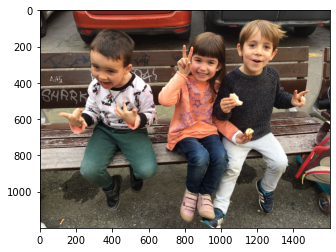

```python
imgplot = plt.imshow(img2)
```

**Eliminem el canal G Verd:**

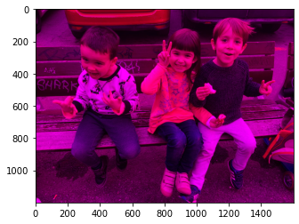

```python
img2[:,:,1]=0
plt.imshow(img2)
```

```python
mpimg.imsave ("imagen_sin_Verde.jpg",img2) # grabamos la imagen
```

**Eliminem el canal B blau:**

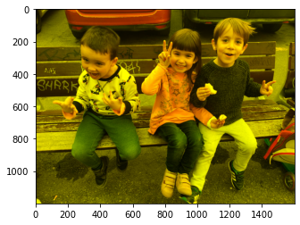

```python
img3=img.copy()
img3[:,:,2]=0
plt.imshow(img3)
```

```python
mpimg.imsave ("imagen_sin_Azul.jpg",img3) # grabamos la imagen
```